# Project: TMDb Movie Data Analysis

**Udacity Data Analysis Nanodegree**  
Project Investigate a Dataset  
Adriano Arruda Ramos  
June 22, 2020

- Introduction
- Data Wrangling
- Exploratory Data Analysis
- Conclusions

## Introduction

The Movie Database [TMDb](https://www.themoviedb.org) is a community built movie and TV database. The following data analysis is based on TMDb dataset adapted from the [original dataset](https://www.kaggle.com/tmdb/tmdb-movie-metadata) available in Kaggle. For the purposes of this analysis, I will adopt the name of movie for both movies and TV series.

```python
# importing packages

import numpy as np
import pandas as pd
import matplotlib.pyplot as plt
import seaborn as sns
%matplotlib inline
```

## Data Wrangling

After importing the dataset, I will do a recognition and an initial exploration to have the first contact with the data, to know its size or volume, column or variable names, data type, possible missing data, an initial reading for general knowledge about the dataset.  
According to the section below, we have 21 variables and 10866 movie records. The variables with the largest amount of null or missing data are: homepage, tagline and keywords.

### General Properties

```python
# Importing the dataset TMDB Movies
df = pd.read_csv('tmdb-movies.csv')
df.head()
```

|  | id | imdb_id | popularity | budget | revenue | original_title | cast | homepage | director | tagline | ... | overview | runtime | genres | production_companies | release_date | vote_count | vote_average | release_year | budget_adj | revenue_adj |
| --- | --- | --- | --- | --- | --- | --- | --- | --- | --- | --- | --- | --- | --- | --- | --- | --- | --- | --- | --- | --- | --- |
| 0 | 135397 | tt0369610 | 32.985763 | 150000000 | 1513528810 | Jurassic World | Chris Pratt\|Bryce Dallas Howard\|Irrfan Khan\|Vi... | http://www.jurassicworld.com/ | Colin Trevorrow | The park is open. | ... | Twenty-two years after the events of Jurassic ... | 124 | Action\|Adventure\|Science Fiction\|Thriller | Universal Studios\|Amblin Entertainment\|Legenda... | 6/9/15 | 5562 | 6.5 | 2015 | 1.379999e+08 | 1.392446e+09 |
| 1 | 76341 | tt1392190 | 28.419936 | 150000000 | 378436354 | Mad Max: Fury Road | Tom Hardy\|Charlize Theron\|Hugh Keays-Byrne\|Nic... | http://www.madmaxmovie.com/ | George Miller | What a Lovely Day. | ... | An apocalyptic story set in the furthest reach... | 120 | Action\|Adventure\|Science Fiction\|Thriller | Village Roadshow Pictures\|Kennedy Miller Produ... | 5/13/15 | 6185 | 7.1 | 2015 | 1.379999e+08 | 3.481613e+08 |
| 2 | 262500 | tt2908446 | 13.112507 | 110000000 | 295238201 | Insurgent | Shailene Woodley\|Theo James\|Kate Winslet\|Ansel... | http://www.thedivergentseries.movie/#insurgent | Robert Schwentke | One Choice Can Destroy You | ... | Beatrice Prior must confront her inner demons ... | 119 | Adventure\|Science Fiction\|Thriller | Summit Entertainment\|Mandeville Films\|Red Wago... | 3/18/15 | 2480 | 6.3 | 2015 | 1.012000e+08 | 2.716190e+08 |
| 3 | 140607 | tt2488496 | 11.173104 | 200000000 | 2068178225 | Star Wars: The Force Awakens | Harrison Ford\|Mark Hamill\|Carrie Fisher\|Adam D... | http://www.starwars.com/films/star-wars-episod... | J.J. Abrams | Every generation has a story. | ... | Thirty years after defeating the Galactic Empi... | 136 | Action\|Adventure\|Science Fiction\|Fantasy | Lucasfilm\|Truenorth Productions\|Bad Robot | 12/15/15 | 5292 | 7.5 | 2015 | 1.839999e+08 | 1.902723e+09 |
| 4 | 168259 | tt2820852 | 9.335014 | 190000000 | 1506249360 | Furious 7 | Vin Diesel\|Paul Walker\|Jason Statham\|Michelle ... | http://www.furious7.com/ | James Wan | Vengeance Hits Home | ... | Deckard Shaw seeks revenge against Dominic Tor... | 137 | Action\|Crime\|Thriller | Universal Pictures\|Original Film\|Media Rights ... | 4/1/15 | 2947 | 7.3 | 2015 | 1.747999e+08 | 1.385749e+09 |

5 rows × 21 columns

```python
# Columns name
df.columns
```

```
Index(['id', 'imdb_id', 'popularity', 'budget', 'revenue', 'original_title',
       'cast', 'homepage', 'director', 'tagline', 'keywords', 'overview',
       'runtime', 'genres', 'production_companies', 'release_date',
       'vote_count', 'vote_average', 'release_year', 'budget_adj',
       'revenue_adj'],
      dtype='object')
```

```python
# DataFrame data volume identification
print("Entries:\t {}".format(df.shape[0]))
print("Variables:\t {}\n".format(df.shape[1]))

# Dataset data types
display(df.dtypes)
```

```
Entries:	 10866
Variables:	 21
```

```
id                        int64
imdb_id                  object
popularity              float64
budget                    int64
revenue                   int64
original_title           object
cast                     object
homepage                 object
director                 object
tagline                  object
keywords                 object
overview                 object
runtime                   int64
genres                   object
production_companies     object
release_date             object
vote_count                int64
vote_average            float64
release_year              int64
budget_adj              float64
revenue_adj             float64
dtype: object
```

```python
# Amount of non-null data and data types per column
df.info()
```

```
<class 'pandas.core.frame.DataFrame'>
RangeIndex: 10866 entries, 0 to 10865
Data columns (total 21 columns):
 #   Column                Non-Null Count  Dtype
---  ------                --------------  -----
 0   id                    10866 non-null  int64
 1   imdb_id               10856 non-null  object
 2   popularity            10866 non-null  float64
 3   budget                10866 non-null  int64
 4   revenue               10866 non-null  int64
 5   original_title        10866 non-null  object
 6   cast                  10790 non-null  object
 7   homepage              2936 non-null   object
 8   director              10822 non-null  object
 9   tagline               8042 non-null   object
 10  keywords              9373 non-null   object
 11  overview              10862 non-null  object
 12  runtime               10866 non-null  int64
 13  genres                10843 non-null  object
 14  production_companies  9836 non-null   object
 15  release_date          10866 non-null  object
 16  vote_count            10866 non-null  int64
 17  vote_average          10866 non-null  float64
 18  release_year          10866 non-null  int64
 19  budget_adj            10866 non-null  float64
 20  revenue_adj           10866 non-null  float64
dtypes: float64(4), int64(6), object(11)
memory usage: 1.7+ MB
```

```python
# Sorting the variables in descending order by their missing values
(df.isnull().sum() / df.shape[0]).sort_values(ascending = False)
```

```
homepage                0.729799
tagline                 0.259893
keywords                0.137401
production_companies    0.094791
cast                    0.006994
director                0.004049
genres                  0.002117
imdb_id                 0.000920
overview                0.000368
popularity              0.000000
budget                  0.000000
revenue                 0.000000
original_title          0.000000
revenue_adj             0.000000
budget_adj              0.000000
runtime                 0.000000
release_date            0.000000
vote_count              0.000000
vote_average            0.000000
release_year            0.000000
id                      0.000000
dtype: float64
```

```python
# A brief description for some statitical number for the dataset
df.describe()
```

|  | id | popularity | budget | revenue | runtime | vote_count | vote_average | release_year | budget_adj | revenue_adj |
| --- | --- | --- | --- | --- | --- | --- | --- | --- | --- | --- |
| count | 10866.000000 | 10866.000000 | 1.086600e+04 | 1.086600e+04 | 10866.000000 | 10866.000000 | 10866.000000 | 10866.000000 | 1.086600e+04 | 1.086600e+04 |
| mean | 66064.177434 | 0.646441 | 1.462570e+07 | 3.982332e+07 | 102.070863 | 217.389748 | 5.974922 | 2001.322658 | 1.755104e+07 | 5.136436e+07 |
| std | 92130.136561 | 1.000185 | 3.091321e+07 | 1.170035e+08 | 31.381405 | 575.619058 | 0.935142 | 12.812941 | 3.430616e+07 | 1.446325e+08 |
| min | 5.000000 | 0.000065 | 0.000000e+00 | 0.000000e+00 | 0.000000 | 10.000000 | 1.500000 | 1960.000000 | 0.000000e+00 | 0.000000e+00 |
| 25% | 10596.250000 | 0.207583 | 0.000000e+00 | 0.000000e+00 | 90.000000 | 17.000000 | 5.400000 | 1995.000000 | 0.000000e+00 | 0.000000e+00 |
| 50% | 20669.000000 | 0.383856 | 0.000000e+00 | 0.000000e+00 | 99.000000 | 38.000000 | 6.000000 | 2006.000000 | 0.000000e+00 | 0.000000e+00 |
| 75% | 75610.000000 | 0.713817 | 1.500000e+07 | 2.400000e+07 | 111.000000 | 145.750000 | 6.600000 | 2011.000000 | 2.085325e+07 | 3.369710e+07 |
| max | 417859.000000 | 32.985763 | 4.250000e+08 | 2.781506e+09 | 900.000000 | 9767.000000 | 9.200000 | 2015.000000 | 4.250000e+08 | 2.827124e+09 |

Exploring some variables that may not add much value to my analysis. So I will remove some columns that I do not intend to use in the analysis.

```python
df[["imdb_id", "homepage", "tagline", "budget", "budget_adj", "revenue", "revenue_adj"]].head()
```

|  | imdb_id | homepage | tagline | budget | budget_adj | revenue | revenue_adj |
| --- | --- | --- | --- | --- | --- | --- | --- |
| 0 | tt0369610 | http://www.jurassicworld.com/ | The park is open. | 150000000 | 1.379999e+08 | 1513528810 | 1.392446e+09 |
| 1 | tt1392190 | http://www.madmaxmovie.com/ | What a Lovely Day. | 150000000 | 1.379999e+08 | 378436354 | 3.481613e+08 |
| 2 | tt2908446 | http://www.thedivergentseries.movie/#insurgent | One Choice Can Destroy You | 110000000 | 1.012000e+08 | 295238201 | 2.716190e+08 |
| 3 | tt2488496 | http://www.starwars.com/films/star-wars-episod... | Every generation has a story. | 200000000 | 1.839999e+08 | 2068178225 | 1.902723e+09 |
| 4 | tt2820852 | http://www.furious7.com/ | Vengeance Hits Home | 190000000 | 1.747999e+08 | 1506249360 | 1.385749e+09 |

Of the 4 variables with the largest number of missing data, 2 of them I do not intend to use for this analysis: *homepage* and *tagline*. Another variable that will not contribute much to the analysis is *imdb_id*. So I will exclude them from the temporary dataset that we will create for analysis. There are two types of variables for *budget* and *revenue* (data types *float64* and *int64*), both without nulls. I will use the *budget* and *revenue* variables of type *int64*, by personal decision. Without a technical factor that can justify such a decision, I just chose to keep a type of each variable in the dataset that I will use in the analysis.

```python
# Dropping the columns imdb_id, homepage, tagline, budget_adj and revenue_adj
df.drop(["imdb_id", "homepage", "tagline", "budget_adj", "revenue_adj"], axis=1, inplace=True)

df.head()
```

|  | id | popularity | budget | revenue | original_title | cast | director | keywords | overview | runtime | genres | production_companies | release_date | vote_count | vote_average | release_year |
| --- | --- | --- | --- | --- | --- | --- | --- | --- | --- | --- | --- | --- | --- | --- | --- | --- |
| 0 | 135397 | 32.985763 | 150000000 | 1513528810 | Jurassic World | Chris Pratt\|Bryce Dallas Howard\|Irrfan Khan\|Vi... | Colin Trevorrow | monster\|dna\|tyrannosaurus rex\|velociraptor\|island | Twenty-two years after the events of Jurassic ... | 124 | Action\|Adventure\|Science Fiction\|Thriller | Universal Studios\|Amblin Entertainment\|Legenda... | 6/9/15 | 5562 | 6.5 | 2015 |
| 1 | 76341 | 28.419936 | 150000000 | 378436354 | Mad Max: Fury Road | Tom Hardy\|Charlize Theron\|Hugh Keays-Byrne\|Nic... | George Miller | future\|chase\|post-apocalyptic\|dystopia\|australia | An apocalyptic story set in the furthest reach... | 120 | Action\|Adventure\|Science Fiction\|Thriller | Village Roadshow Pictures\|Kennedy Miller Produ... | 5/13/15 | 6185 | 7.1 | 2015 |
| 2 | 262500 | 13.112507 | 110000000 | 295238201 | Insurgent | Shailene Woodley\|Theo James\|Kate Winslet\|Ansel... | Robert Schwentke | based on novel\|revolution\|dystopia\|sequel\|dyst... | Beatrice Prior must confront her inner demons ... | 119 | Adventure\|Science Fiction\|Thriller | Summit Entertainment\|Mandeville Films\|Red Wago... | 3/18/15 | 2480 | 6.3 | 2015 |
| 3 | 140607 | 11.173104 | 200000000 | 2068178225 | Star Wars: The Force Awakens | Harrison Ford\|Mark Hamill\|Carrie Fisher\|Adam D... | J.J. Abrams | android\|spaceship\|jedi\|space opera\|3d | Thirty years after defeating the Galactic Empi... | 136 | Action\|Adventure\|Science Fiction\|Fantasy | Lucasfilm\|Truenorth Productions\|Bad Robot | 12/15/15 | 5292 | 7.5 | 2015 |
| 4 | 168259 | 9.335014 | 190000000 | 1506249360 | Furious 7 | Vin Diesel\|Paul Walker\|Jason Statham\|Michelle ... | James Wan | car race\|speed\|revenge\|suspense\|car | Deckard Shaw seeks revenge against Dominic Tor... | 137 | Action\|Crime\|Thriller | Universal Pictures\|Original Film\|Media Rights ... | 4/1/15 | 2947 | 7.3 | 2015 |

```python
# Data volume identification
print("Entries:\t {}".format(df.shape[0]))
print("Variables:\t {}\n".format(df.shape[1]))

# Dataset data types
display(df.dtypes)
```

```
Entries:	 10866
Variables:	 16
```

```
id                        int64
popularity              float64
budget                    int64
revenue                   int64
original_title           object
cast                     object
director                 object
keywords                 object
overview                 object
runtime                   int64
genres                   object
production_companies     object
release_date             object
vote_count                int64
vote_average            float64
release_year              int64
dtype: object
```

```python
# Amount of non-null data and data types per column in the dataset
df.info()
```

```
<class 'pandas.core.frame.DataFrame'>
RangeIndex: 10866 entries, 0 to 10865
Data columns (total 16 columns):
 #   Column                Non-Null Count  Dtype
---  ------                --------------  -----
 0   id                    10866 non-null  int64
 1   popularity            10866 non-null  float64
 2   budget                10866 non-null  int64
 3   revenue               10866 non-null  int64
 4   original_title        10866 non-null  object
 5   cast                  10790 non-null  object
 6   director              10822 non-null  object
 7   keywords              9373 non-null   object
 8   overview              10862 non-null  object
 9   runtime               10866 non-null  int64
 10  genres                10843 non-null  object
 11  production_companies  9836 non-null   object
 12  release_date          10866 non-null  object
 13  vote_count            10866 non-null  int64
 14  vote_average          10866 non-null  float64
 15  release_year          10866 non-null  int64
dtypes: float64(2), int64(6), object(8)
memory usage: 1.3+ MB
```

```python
# A brief description for some statitical numbers of the dataset
df.describe()
```

|  | id | popularity | budget | revenue | runtime | vote_count | vote_average | release_year |
| --- | --- | --- | --- | --- | --- | --- | --- | --- |
| count | 10866.000000 | 10866.000000 | 1.086600e+04 | 1.086600e+04 | 10866.000000 | 10866.000000 | 10866.000000 | 10866.000000 |
| mean | 66064.177434 | 0.646441 | 1.462570e+07 | 3.982332e+07 | 102.070863 | 217.389748 | 5.974922 | 2001.322658 |
| std | 92130.136561 | 1.000185 | 3.091321e+07 | 1.170035e+08 | 31.381405 | 575.619058 | 0.935142 | 12.812941 |
| min | 5.000000 | 0.000065 | 0.000000e+00 | 0.000000e+00 | 0.000000 | 10.000000 | 1.500000 | 1960.000000 |
| 25% | 10596.250000 | 0.207583 | 0.000000e+00 | 0.000000e+00 | 90.000000 | 17.000000 | 5.400000 | 1995.000000 |
| 50% | 20669.000000 | 0.383856 | 0.000000e+00 | 0.000000e+00 | 99.000000 | 38.000000 | 6.000000 | 2006.000000 |
| 75% | 75610.000000 | 0.713817 | 1.500000e+07 | 2.400000e+07 | 111.000000 | 145.750000 | 6.600000 | 2011.000000 |
| max | 417859.000000 | 32.985763 | 4.250000e+08 | 2.781506e+09 | 900.000000 | 9767.000000 | 9.200000 | 2015.000000 |

After summarizing some descriptive statistics generated by the describe method of Pandas we have some initial numbers from our dataset. In this summary, missing values are excluded.  
We can see that the oldest movie in the dataset was released in 1960 and the newest one in 2015, with most of the movies being released between mid 2000 and 2015. The average vote score was 5.97, with most of the votes between 5 and 7. Only 1/4 of the movies had more than 145 votes, the movie with the least votes had 10 votes and the one with the most votes obtained 9767 vote records. And more than half of the movies have a budget and revenue as zero.  
We can see these numbers reflected in the histogram graphs below.

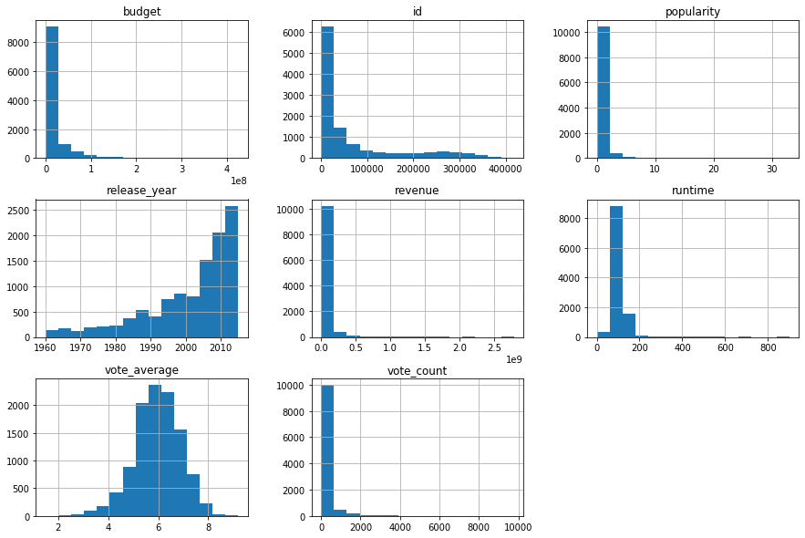

```python
# Histogram of the original dataset
df.hist(bins = 15, figsize = (15,10));
```

### Preliminary analysis and possible questions

My main question to be investigated in the dataset is whether there is a possible relationship between genres of films, their popularity, their revenue and profit. Or what kinds of properties are associated with movies that have high revenues.

```python
# Putting revenues in descending order
df.revenue.sort_values(ascending = False)
```

```
1386     2781505847
3        2068178225
5231     1845034188
4361     1519557910
0        1513528810
            ...
4549              0
4551              0
4552              0
4553              0
10865             0
Name: revenue, Length: 10866, dtype: int64
```

```python
# Creating a filter for movies with revenues exceeding 100 million
filter_revenue_100MM = df["revenue"] > 100000000

print("Revenues greater than 100 million: {} movies".format(df[ filter_revenue_100MM ]["id"].count()))
```

```
Revenues greater than 100 million: 1209 movies
```

```python
# Some characteristics of movies with revenues above 100 million
df[ filter_revenue_100MM ].describe()
```

|  | id | popularity | budget | revenue | runtime | vote_count | vote_average | release_year |
| --- | --- | --- | --- | --- | --- | --- | --- | --- |
| count | 1209.000000 | 1209.000000 | 1.209000e+03 | 1.209000e+03 | 1209.000000 | 1209.000000 | 1209.000000 | 1209.000000 |
| mean | 37572.292804 | 2.112225 | 7.051217e+07 | 2.783668e+08 | 115.368900 | 1181.149711 | 6.375021 | 2003.067825 |
| std | 64732.278329 | 2.166036 | 5.424711e+07 | 2.358132e+08 | 26.882647 | 1260.605222 | 0.708771 | 9.690510 |
| min | 11.000000 | 0.131526 | 0.000000e+00 | 1.000201e+08 | 72.000000 | 10.000000 | 4.200000 | 1961.000000 |
| 25% | 1726.000000 | 1.014707 | 3.000000e+07 | 1.356800e+08 | 99.000000 | 354.000000 | 5.900000 | 1998.000000 |
| 50% | 9552.000000 | 1.554808 | 5.900000e+07 | 1.953128e+08 | 113.000000 | 728.000000 | 6.400000 | 2005.000000 |
| 75% | 43347.000000 | 2.487042 | 9.500000e+07 | 3.265511e+08 | 127.000000 | 1545.000000 | 6.900000 | 2011.000000 |
| max | 417859.000000 | 32.985763 | 3.800000e+08 | 2.781506e+09 | 705.000000 | 9767.000000 | 8.300000 | 2015.000000 |

In the describe method we see that the summary shows some movies with zero budgets in the set of movies with revenues above 100 million.

```python
# Budgets with zero values, but revenues above 100 MM

df[ filter_revenue_100MM ].sort_values(by='budget', ascending=True, na_position='first').head()
```

|  | id | popularity | budget | revenue | original_title | cast | director | keywords | overview | runtime | genres | production_companies | release_date | vote_count | vote_average | release_year |
| --- | --- | --- | --- | --- | --- | --- | --- | --- | --- | --- | --- | --- | --- | --- | --- | --- |
| 8216 | 9909 | 0.235135 | 0 | 180000000 | Dangerous Minds | Michelle Pfeiffer\|George Dzundza\|Courtney B. V... | John N. Smith | rap\|karate\|high school\|naval officer\|teacher | Former Marine Louanne Johnson lands a gig teac... | 99 | Drama\|Crime | Hollywood Pictures\|Via Rosa Productions\|Don Si... | 8/11/95 | 128 | 6.5 | 1995 |
| 10009 | 11092 | 0.548596 | 0 | 221303188 | Presumed Innocent | Harrison Ford\|Brian Dennehy\|Raúl Juliá\|Bonni... | Alan J. Pakula | loss of lover\|lover (female)\|investigation\|law... | Life takes a nasty twist for D.A. Rusty Sabich... | 127 | Drama\|Thriller\|Crime\|Mystery | Mirage Enterprises\|Warner Bros. | 7/26/90 | 59 | 6.3 | 1990 |
| 10295 | 1049 | 0.502196 | 0 | 140081992 | Sommersby | Jodie Foster\|Richard Gere\|Bill Pullman\|James E... | Jon Amiel | southern u.s.\|wife husband relationship\|amnesi... | Set in the south of the United States just aft... | 109 | Drama\|Thriller\|Mystery\|Romance | Canal Plus\|Regency Enterprises\|Alcor Films | 2/5/93 | 43 | 5.9 | 1993 |
| 1342 | 11006 | 0.541642 | 0 | 126737428 | Smokey and the Bandit | Burt Reynolds\|Sally Field\|Jerry Reed\|Jackie Gl... | Hal Needham | sheriff\|bride\|smuggling\|road movie | A race car driver tries to transport an illega... | 96 | Action\|Adventure\|Comedy | Universal Pictures | 5/26/77 | 93 | 6.9 | 1977 |
| 1381 | 14741 | 0.140163 | 0 | 102000000 | The Goodbye Girl | Richard Dreyfuss\|Marsha Mason\|Quinn Cummings\|P... | Herbert Ross | theatre play | Paula McFadden knows: In romance, actors all f... | 111 | Comedy\|Romance | Rastar Pictures\|Metro-Goldwyn-Mayer (MGM) | 11/30/77 | 10 | 6.5 | 1977 |

Let's investigate these movies a little more.

```python
# Creating a filter for movies with zero value budgets.
filter_budget_zero = df["budget"] < 1
print("Budgets with zero values: {} movies".format(df[ filter_budget_zero ]["id"].count()))
```

```
Budgets with zero values: 5696 movies
```

```python
# Movies with zero value budgets and revenues above 100 MM.
print("Budgets with zero values and revenues above 100 MM: {} movies".format(df[ filter_revenue_100MM & filter_budget_zero ]["id"].count()))
```

```
Budgets with zero values and revenues above 100 MM: 27 movies
```

```python
df[ filter_revenue_100MM & filter_budget_zero ].head(30)
```

|  | id | popularity | budget | revenue | original_title | cast | director | keywords | overview | runtime | genres | production_companies | release_date | vote_count | vote_average | release_year |
| --- | --- | --- | --- | --- | --- | --- | --- | --- | --- | --- | --- | --- | --- | --- | --- | --- |
| 95 | 258509 | 1.841779 | 0 | 233755553 | Alvin and the Chipmunks: The Road Chip | Jason Lee\|Justin Long\|Bella Thorne\|Matthew Gra... | Walt Becker | chipmunk\|cgi\|talking animal\|aftercreditsstinge... | Through a series of misunderstandings, Alvin, ... | 92 | Adventure\|Animation\|Comedy\|Family | Regency Enterprises\|Fox 2000 Pictures\|Sunswept... | 12/17/15 | 278 | 5.7 | 2015 |
| 1342 | 11006 | 0.541642 | 0 | 126737428 | Smokey and the Bandit | Burt Reynolds\|Sally Field\|Jerry Reed\|Jackie Gl... | Hal Needham | sheriff\|bride\|smuggling\|road movie | A race car driver tries to transport an illega... | 96 | Action\|Adventure\|Comedy | Universal Pictures | 5/26/77 | 93 | 6.9 | 1977 |
| 1381 | 14741 | 0.140163 | 0 | 102000000 | The Goodbye Girl | Richard Dreyfuss\|Marsha Mason\|Quinn Cummings\|P... | Herbert Ross | theatre play | Paula McFadden knows: In romance, actors all f... | 111 | Comedy\|Romance | Rastar Pictures\|Metro-Goldwyn-Mayer (MGM) | 11/30/77 | 10 | 6.5 | 1977 |
| 1435 | 12556 | 1.285167 | 0 | 102223269 | Ghosts of Girlfriends Past | Matthew McConaughey\|Jennifer Garner\|Michael Do... | Mark Waters | womanizer\|love\|wedding\|aftercreditsstinger\|dur... | When notorious womanizer Connor Mead attends h... | 100 | Fantasy\|Comedy\|Romance | New Line Cinema\|Jon Shestack Productions\|Panther | 5/1/09 | 452 | 5.5 | 2009 |
| 2722 | 331214 | 0.537593 | 0 | 125000000 | Band of Brothers | Damian Lewis\|Ron Livingston\|Frank John Hughes\|... | Phil Alden Robinson\|Richard Loncraine\|Mikael S... | world war ii\|us army\|war\|paratroops\|combat | Drawn from interviews with survivors of Easy C... | 705 | Action\|Drama\|War | HBO | 9/9/01 | 313 | 8.0 | 2001 |
| 4270 | 1945 | 0.409529 | 0 | 106683817 | Nell | Jodie Foster\|Liam Neeson\|Natasha Richardson\|Ri... | Michael Apted | loss of mother\|loss of sister\|twin sister\|auti... | In a remote woodland cabin, a small town docto... | 112 | Drama\|Thriller | 20th Century Fox\|Egg Pictures | 12/23/94 | 63 | 6.0 | 1994 |
| 4476 | 77953 | 0.802985 | 0 | 104907746 | The Campaign | Dylan McDermott\|Will Ferrell\|Zach Galifianakis... | Jay Roach | politics\|politician\|election campaign\|Â north ... | The film follows two rival politicians (Will F... | 85 | Comedy | Everyman Pictures\|Gary Sanchez Productions\|War... | 8/9/12 | 351 | 5.5 | 2012 |
| 5011 | 1647 | 0.894267 | 0 | 101191884 | The Recruit | Al Pacino\|Colin Farrell\|Bridget Moynahan\|Gabri... | Roger Donaldson | spy\|cia\|extramarital affair | A brilliant young CIA trainee is asked by his ... | 115 | Action\|Thriller\|Crime\|Drama | Spyglass Entertainment\|Touchstone Pictures | 1/25/03 | 290 | 5.9 | 2003 |
| 6230 | 10320 | 1.266058 | 0 | 161451538 | The Ring Two | Naomi Watts\|Simon Baker\|Elizabeth Perkins\|Davi... | Hideo Nakata | bath tub\|nightmare\|son\|vision\|good vs evil | Rachel Keller must prevent evil Samara from ta... | 110 | Drama\|Horror\|Thriller | DreamWorks SKG\|BenderSpink\|Parkes+MacDonald Im... | 3/17/05 | 279 | 5.2 | 2005 |
| 6602 | 9513 | 1.207359 | 0 | 141702264 | Garfield 2 | Bill Murray\|Jennifer Love Hewitt\|Billy Connoll... | Tim Hill | london\|mistake in person\|luxury\|wretch\|kater | Garfield is back and this time Garfield and hi... | 78 | Animation\|Comedy\|Family | Twentieth Century Fox Film Corporation\|Dune En... | 6/15/06 | 260 | 5.2 | 2006 |
| 7003 | 11024 | 1.433373 | 0 | 181466833 | Scooby-Doo 2: Monsters Unleashed | Freddie Prinze Jr.\|Sarah Michelle Gellar\|Matth... | Raja Gosnell | detective\|monster\|engine\|based on tv series\|dog | When Mystery, Inc. are guests of honor at the ... | 93 | Mystery\|Fantasy\|Adventure\|Comedy | Mosaic Media Group\|Warner Bros. | 3/24/04 | 263 | 5.2 | 2004 |
| 7330 | 21629 | 0.427457 | 0 | 101300000 | Stir Crazy | Gene Wilder\|Richard Pryor\|Georg Stanford Brown... | Sidney Poitier | escape from prison\|mistaken identity\|fish out ... | New Yorkers, Skip Donahue and Harry Monroe, ha... | 111 | Comedy | Columbia Pictures Corporation | 12/12/80 | 59 | 6.7 | 1980 |
| 7470 | 11199 | 0.907749 | 0 | 253625427 | Wild Hogs | Tim Allen\|John Travolta\|Martin Lawrence\|Willia... | Walt Becker | politically incorrect\|motorcycle gang\|biker fi... | Restless and ready for adventure, four suburba... | 100 | Action\|Adventure\|Comedy | Wild Hogs Productions\|Touchstone Pictures | 3/2/07 | 361 | 5.6 | 2007 |
| 8099 | 6950 | 1.041497 | 0 | 189859560 | Outbreak | Dustin Hoffman\|Rene Russo\|Morgan Freeman\|Kevin... | Wolfgang Petersen | river\|general\|research\|army\|serum | A deadly airborne virus finds its way into the... | 127 | Action\|Drama\|Science Fiction\|Thriller | Kopelson Entertainment\|Punch Productions\|Warne... | 3/10/95 | 249 | 6.1 | 1995 |
| 8211 | 2054 | 0.421679 | 0 | 106269971 | Mr. Holland's Opus | Richard Dreyfuss\|Glenne Headly\|Jay Thomas\|Olym... | Stephen Herek | composer\|mentor\|deaf-mute\|musical\|apprentice | In 1965, passionate musician Glenn Holland tak... | 137 | Drama\|Family | Hollywood Pictures\|The Charlie Mopic Company\|P... | 12/29/95 | 47 | 6.8 | 1995 |
| 8216 | 9909 | 0.235135 | 0 | 180000000 | Dangerous Minds | Michelle Pfeiffer\|George Dzundza\|Courtney B. V... | John N. Smith | rap\|karate\|high school\|naval officer\|teacher | Former Marine Louanne Johnson lands a gig teac... | 99 | Drama\|Crime | Hollywood Pictures\|Via Rosa Productions\|Don Si... | 8/11/95 | 128 | 6.5 | 1995 |
| 8254 | 11806 | 1.100749 | 0 | 147214049 | Beethoven | Charles Grodin\|Bonnie Hunt\|Dean Jones\|Nicholle... | Brian Levant | puppy\|st. bernard's dog\|family | The Newton family live in their comfortable ho... | 87 | Comedy\|Family | Universal Pictures\|Northern Lights Entertainment | 4/3/92 | 192 | 5.6 | 1992 |
| 8259 | 2322 | 0.883759 | 0 | 105232691 | Sneakers | Robert Redford\|Sidney Poitier\|Dan Aykroyd\|Davi... | Phil Alden Robinson | hacker\|mathematician\|assignment\|company\|comput... | When shadowy U.S. intelligence agents blackmai... | 126 | Adventure\|Drama\|Action\|Comedy\|Thriller | Universal Pictures | 9/9/92 | 165 | 6.6 | 1992 |
| 8297 | 10326 | 0.474174 | 0 | 128000000 | Forever Young | Mel Gibson\|Jamie Lee Curtis\|Elijah Wood\|Isabel... | Steve Miner | test person\|us air force\|airplane\|experiment w... | A 1939 test pilot asks his best friend to use ... | 102 | Adventure\|Fantasy\|Drama\|Science Fiction\|Romance | Icon Entertainment International\|Warner Bros. | 12/16/92 | 143 | 5.8 | 1992 |
| 8551 | 11000 | 0.473009 | 0 | 185260553 | The Birdcage | Robin Williams\|Gene Hackman\|Nathan Lane\|Dianne... | Mike Nichols | gay\|travestie\|homophobia\|gay kiss\|coming out | A gay cabaret owner and his drag queen compani... | 117 | Comedy | Metro-Goldwyn-Mayer (MGM) | 3/8/96 | 149 | 6.8 | 1996 |
| 8597 | 2928 | 0.334345 | 0 | 119718203 | Michael | John Travolta\|Andie MacDowell\|William Hurt\|Bob... | Nora Ephron | angel\|vice\|road trip\|reporter\|dog | Tabloid reporters are sent by their editor to ... | 105 | Comedy\|Drama\|Fantasy | Turner Pictures\|Warner Bros.\|Alphaville Films | 12/25/96 | 84 | 5.5 | 1996 |
| 8914 | 2623 | 0.496761 | 0 | 129795554 | An Officer and a Gentleman | Richard Gere\|Debra Winger\|Louis Gossett, Jr.\|D... | Taylor Hackford | love of one's life\|navy\|officer | Zack Mayo is a young man who has signed up for... | 124 | Drama\|Romance | Paramount Pictures\|Lorimar Film Entertainment | 7/28/82 | 112 | 6.4 | 1982 |
| 9105 | 14444 | 0.301614 | 0 | 100491683 | The Rugrats Movie | Whoopi Goldberg\|David Spade\|E.G. Daily\|Tara St... | Norton Virgien\|Igor Kovalyov | brother brother relationship\|baby\|home\|pregnan... | Tommy faces responsibility when Dil, his new b... | 79 | Animation\|Family | Nickelodeon Movies\|Paramount Animation | 11/20/98 | 79 | 5.6 | 1998 |
| 9210 | 1552 | 0.547789 | 0 | 126297830 | Parenthood | Steve Martin\|Mary Steenburgen\|Dianne Wiest\|Jas... | Ron Howard | parents kids relationship\|kids | The story of the Buckman family and friends, a... | 124 | Comedy\|Drama\|Family | Imagine Entertainment\|Universal Pictures | 7/31/89 | 70 | 6.2 | 1989 |
| 9467 | 9396 | 0.838320 | 0 | 239606210 | Crocodile Dundee II | Paul Hogan\|Linda Kozlowski\|John Meillon\|Ernie ... | John Cornell | new york\|crocodile\|australia\|large knife\|after... | Australian outback expert protects his New Yor... | 110 | Adventure\|Comedy | Paramount Pictures | 5/19/88 | 159 | 5.5 | 1988 |
| 10009 | 11092 | 0.548596 | 0 | 221303188 | Presumed Innocent | Harrison Ford\|Brian Dennehy\|Raúl Juliá\|Bonni... | Alan J. Pakula | loss of lover\|lover (female)\|investigation\|law... | Life takes a nasty twist for D.A. Rusty Sabich... | 127 | Drama\|Thriller\|Crime\|Mystery | Mirage Enterprises\|Warner Bros. | 7/26/90 | 59 | 6.3 | 1990 |
| 10295 | 1049 | 0.502196 | 0 | 140081992 | Sommersby | Jodie Foster\|Richard Gere\|Bill Pullman\|James E... | Jon Amiel | southern u.s.\|wife husband relationship\|amnesi... | Set in the south of the United States just aft... | 109 | Drama\|Thriller\|Mystery\|Romance | Canal Plus\|Regency Enterprises\|Alcor Films | 2/5/93 | 43 | 5.9 | 1993 |

```python
df[ filter_revenue_100MM & filter_budget_zero ].shape
```

```
(27, 16)
```

After researching the IMDB website, I found that the budgets for these movies are really missing.

```python
# Worse 5 revenues above 100 MM

df[ filter_revenue_100MM ].sort_values(by='revenue', ascending=True, na_position='first').head()
```

|  | id | popularity | budget | revenue | original_title | cast | director | keywords | overview | runtime | genres | production_companies | release_date | vote_count | vote_average | release_year |
| --- | --- | --- | --- | --- | --- | --- | --- | --- | --- | --- | --- | --- | --- | --- | --- | --- |
| 2704 | 12103 | 0.651040 | 50000000 | 100020092 | Don't Say a Word | Michael Douglas\|Sean Bean\|Brittany Murphy\|Skye... | Gary Fleder | cemetery\|diamant\|suspense\|psychiatrist\|killer | When the daughter of a psychiatrist is kidnapp... | 113 | Thriller | 20th Century Fox\|Village Roadshow Pictures\|NPV... | 9/28/01 | 106 | 6.1 | 2001 |
| 3193 | 10488 | 0.768409 | 37000000 | 100076342 | Nim's Island | Abigail Breslin\|Jodie Foster\|Gerard Butler\|Mic... | Jennifer Flackett\|Mark Levin | fictional place\|exotic island\|shipwreck\|cruise... | A young girl inhabits an isolated island with ... | 96 | Adventure\|Comedy\|Family\|Fantasy | Walden Media | 4/3/08 | 183 | 5.5 | 2008 |
| 1492 | 16523 | 0.786390 | 100000000 | 100086793 | Where the Wild Things Are | Max Records\|Catherine Keener\|Lauren Ambrose\|Ja... | Spike Jonze | children's book\|igloo\|wolf costume\|swallowed w... | Max imagines running away from his mom and sai... | 101 | Family\|Fantasy | Village Roadshow Pictures\|Legendary Pictures\|P... | 10/16/09 | 312 | 6.3 | 2009 |
| 5846 | 205220 | 0.227851 | 12000000 | 100129872 | Philomena | Judi Dench\|Steve Coogan\|Sophie Kennedy Clark\|M... | Stephen Frears | mother\|washington d.c.\|journalist\|aids\|adoption | A woman searches for her adult son, who was ta... | 98 | Drama | BBC Films\|The Weinstein Company\|Baby Cow Produ... | 11/1/13 | 360 | 7.4 | 2013 |
| 8464 | 10545 | 1.894423 | 100000000 | 100138851 | The Hunchback of Notre Dame | Tom Hulce\|Demi Moore\|Heidi Mollenhauer\|Tony Ja... | Gary Trousdale\|Kirk Wise | sword\|mockery\|ugliness\|cathedral\|fool | When Quasi defies the evil Frollo and ventures... | 91 | Family\|Fantasy\|Animation | Walt Disney Pictures | 6/21/96 | 605 | 6.6 | 1996 |

```python
# Top 5 revenues

df[ filter_revenue_100MM ].sort_values(by='revenue', ascending=False, na_position='first').head()
```

|  | id | popularity | budget | revenue | original_title | cast | director | keywords | overview | runtime | genres | production_companies | release_date | vote_count | vote_average | release_year |
| --- | --- | --- | --- | --- | --- | --- | --- | --- | --- | --- | --- | --- | --- | --- | --- | --- |
| 1386 | 19995 | 9.432768 | 237000000 | 2781505847 | Avatar | Sam Worthington\|Zoe Saldana\|Sigourney Weaver\|S... | James Cameron | culture clash\|future\|space war\|space colony\|so... | In the 22nd century, a paraplegic Marine is di... | 162 | Action\|Adventure\|Fantasy\|Science Fiction | Ingenious Film Partners\|Twentieth Century Fox ... | 12/10/09 | 8458 | 7.1 | 2009 |
| 3 | 140607 | 11.173104 | 200000000 | 2068178225 | Star Wars: The Force Awakens | Harrison Ford\|Mark Hamill\|Carrie Fisher\|Adam D... | J.J. Abrams | android\|spaceship\|jedi\|space opera\|3d | Thirty years after defeating the Galactic Empi... | 136 | Action\|Adventure\|Science Fiction\|Fantasy | Lucasfilm\|Truenorth Productions\|Bad Robot | 12/15/15 | 5292 | 7.5 | 2015 |
| 5231 | 597 | 4.355219 | 200000000 | 1845034188 | Titanic | Kate Winslet\|Leonardo DiCaprio\|Frances Fisher\|... | James Cameron | shipwreck\|iceberg\|ship\|panic\|titanic | 84 years later, a 101-year-old woman named Ros... | 194 | Drama\|Romance\|Thriller | Paramount Pictures\|Twentieth Century Fox Film ... | 11/18/97 | 4654 | 7.3 | 1997 |
| 4361 | 24428 | 7.637767 | 220000000 | 1519557910 | The Avengers | Robert Downey Jr.\|Chris Evans\|Mark Ruffalo\|Chr... | Joss Whedon | new york\|shield\|marvel comic\|comic\|superhero | When an unexpected enemy emerges and threatens... | 143 | Science Fiction\|Action\|Adventure | Marvel Studios | 4/25/12 | 8903 | 7.3 | 2012 |
| 0 | 135397 | 32.985763 | 150000000 | 1513528810 | Jurassic World | Chris Pratt\|Bryce Dallas Howard\|Irrfan Khan\|Vi... | Colin Trevorrow | monster\|dna\|tyrannosaurus rex\|velociraptor\|island | Twenty-two years after the events of Jurassic ... | 124 | Action\|Adventure\|Science Fiction\|Thriller | Universal Studios\|Amblin Entertainment\|Legenda... | 6/9/15 | 5562 | 6.5 | 2015 |

```python
# Creating a filter for movies with revenues exceeding 1 billion
filter_revenue_1B = df["revenue"] > 1000000000

print("Revenues greater than 1 billion: {} movies".format(df[ filter_revenue_1B ]["id"].count()))

df[ filter_revenue_1B ].describe()
```

```
Revenues greater than 1 billion: 22 movies
```

|  | id | popularity | budget | revenue | runtime | vote_count | vote_average | release_year |
| --- | --- | --- | --- | --- | --- | --- | --- | --- |
| count | 22.000000 | 22.000000 | 2.200000e+01 | 2.200000e+01 | 22.000000 | 22.000000 | 22.000000 | 22.00000 |
| mean | 54171.545455 | 7.108372 | 1.910000e+08 | 1.333942e+09 | 140.272727 | 4779.727273 | 7.036364 | 2010.00000 |
| std | 62657.427738 | 6.312792 | 7.353587e+07 | 4.282809e+08 | 28.010511 | 2257.719080 | 0.627577 | 5.45981 |
| min | 58.000000 | 0.760503 | 2.200000e+07 | 1.001922e+09 | 91.000000 | 201.000000 | 5.600000 | 1995.00000 |
| 25% | 3947.000000 | 4.502948 | 1.587500e+08 | 1.069505e+09 | 125.500000 | 3005.250000 | 6.575000 | 2009.25000 |
| 50% | 31076.000000 | 5.828121 | 2.000000e+08 | 1.140239e+09 | 139.000000 | 4479.000000 | 7.200000 | 2011.50000 |
| 75% | 92076.000000 | 7.579366 | 2.150000e+08 | 1.480946e+09 | 153.500000 | 6347.000000 | 7.500000 | 2013.00000 |
| max | 211672.000000 | 32.985763 | 3.800000e+08 | 2.781506e+09 | 201.000000 | 8903.000000 | 8.100000 | 2015.00000 |

Investigating movie genres.

```python
df["genres"].head(10)
```

```
0    Action|Adventure|Science Fiction|Thriller
1    Action|Adventure|Science Fiction|Thriller
2           Adventure|Science Fiction|Thriller
3     Action|Adventure|Science Fiction|Fantasy
4                        Action|Crime|Thriller
5             Western|Drama|Adventure|Thriller
6    Science Fiction|Action|Thriller|Adventure
7              Drama|Adventure|Science Fiction
8            Family|Animation|Adventure|Comedy
9                      Comedy|Animation|Family
Name: genres, dtype: object
```

```python
# List of genres
genres_df = df.genres.str.get_dummies('|')
genres = genres_df.columns.to_list()
genres
```

```
['Action',
 'Adventure',
 'Animation',
 'Comedy',
 'Crime',
 'Documentary',
 'Drama',
 'Family',
 'Fantasy',
 'Foreign',
 'History',
 'Horror',
 'Music',
 'Mystery',
 'Romance',
 'Science Fiction',
 'TV Movie',
 'Thriller',
 'War',
 'Western']
```

Totals of movies by genre, remembering that a movie can be classified in more than one genre.

```python
# Totals of movies by genre
total_movies_per_genero = df.genres.str.get_dummies().sum()
total_movies_per_genero
```

```
Action             2385
Adventure          1471
Animation           699
Comedy             3793
Crime              1355
Documentary         520
Drama              4761
Family             1231
Fantasy             916
Foreign             188
History             334
Horror             1637
Music               408
Mystery             810
Romance            1712
Science Fiction    1230
TV Movie            167
Thriller           2908
War                 270
Western             165
dtype: int64
```

We can view the distribution of movie genres by the bar graph below, with all the movies in the dataset.

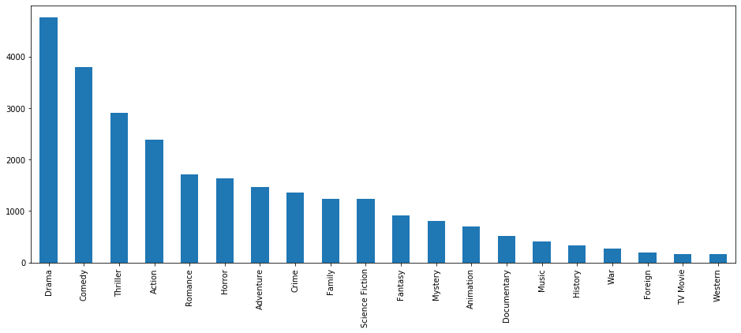

```python
total_movies_per_genero.sort_values(ascending=False).plot(kind='bar', figsize=(16, 6));
```

Distribution of movies genres by the bar chart below, with revenues above 100 million in the dataset.

```python
# Totals of movies by genre, for movies with revenues exceeding 100 million
total_movies_per_genero_revenue_100MM = df.genres[ filter_revenue_100MM ].str.get_dummies().sum()
total_movies_per_genero_revenue_100MM
```

```
Action             450
Adventure          387
Animation          129
Comedy             445
Crime              175
Documentary          2
Drama              417
Family             234
Fantasy            207
History             34
Horror              86
Music               40
Mystery            102
Romance            187
Science Fiction    210
Thriller           350
War                 43
Western             18
dtype: int64
```

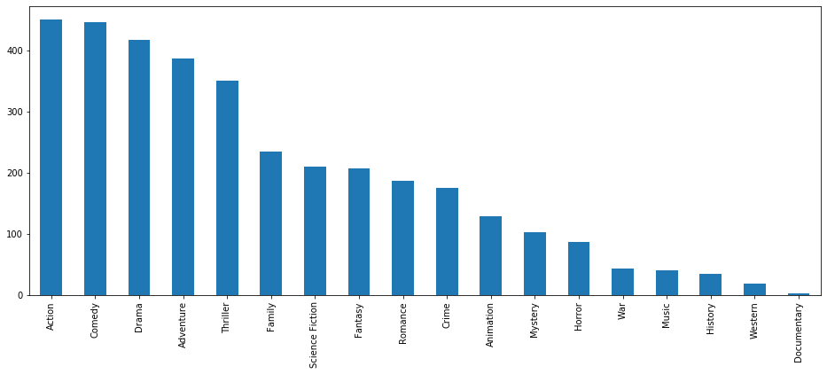

```python
total_movies_per_genero_revenue_100MM.sort_values(ascending=False).plot(kind='bar', figsize=(16, 6));
```

And revenues above 1 billion.

```python
# Totals of movies by genre, for movies with revenues exceeding 1 billion
total_movies_per_genero_revenue_1B = df.genres[ filter_revenue_1B ].str.get_dummies().sum()
total_movies_per_genero_revenue_1B
```

```
Action             16
Adventure          16
Animation           3
Comedy              2
Crime               4
Drama               4
Family              5
Fantasy             8
Mystery             1
Romance             1
Science Fiction     7
Thriller            7
dtype: int64
```

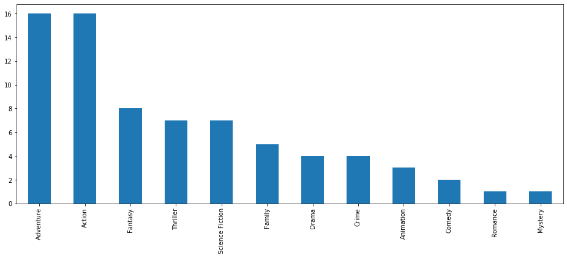

```python
total_movies_per_genero_revenue_1B.sort_values(ascending=False).plot(kind='bar', figsize=(16, 6));
```

## Exploratory Data Analysis

We can conclude that the *Drama* genre is one of the most common in the entire dataset. However, among movies with revenues above 100 million, other genres also stand out, such as: *Action*, *Comedy*, *Adventure* and *Thriller*. In movies with revenues above 1 billion, the two most prominent genres were *Action* and *Adventure*.

### Investigating more about revenue and other possible relationships

Now I will investigate possible relations between revenue and other variables in the dataset, such as popularity, number of votes (vote_count), average grade of votes (vote_average) and even a new variable created from the budget and revenue variables, the profit variable.

```python
# Function to calculate profit from budget and revenue columns
def profit(row):
    return row["revenue"] - row["budget"]
```

```python
df.apply(profit, axis=1)
```

```
0        1363528810
1         228436354
2         185238201
3        1868178225
4        1316249360
            ...
10861             0
10862             0
10863             0
10864             0
10865        -19000
Length: 10866, dtype: int64
```

```python
# Creating the profit column in the dataset
profit = df.apply(profit, axis=1)
df["profit"] = profit

df.columns
```

```
Index(['id', 'popularity', 'budget', 'revenue', 'original_title', 'cast',
       'director', 'keywords', 'overview', 'runtime', 'genres',
       'production_companies', 'release_date', 'vote_count', 'vote_average',
       'release_year', 'profit'],
      dtype='object')
```

```python
# Top 100 profit
df_top100_profit = df.nlargest(100, columns='profit').tail(100)
```

```python
# Totals of movies by genre, for movies with revenues exceeding 100 million and budget not zero
total_movies_per_genero_top100_profit = df_top100_profit.genres.str.get_dummies().sum()
total_movies_per_genero_top100_profit
```

```
Action             52
Adventure          73
Animation          19
Comedy             15
Crime               7
Drama              15
Family             31
Fantasy            39
Mystery             5
Romance             9
Science Fiction    32
Thriller           18
War                 1
dtype: int64
```

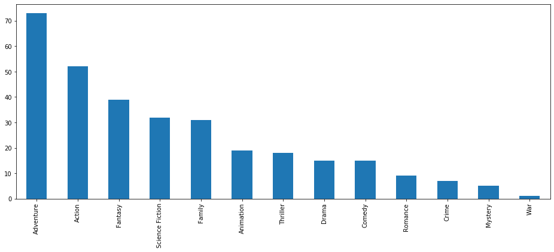

```python
total_movies_per_genero_top100_profit.sort_values(ascending=False).plot(kind='bar', figsize=(16, 6));
```

```python
# Top 5 vote_average, but relevant budget and revenue

df[ filter_revenue_100MM ].sort_values(by='vote_average', ascending=False, na_position='first').head()
```

|  | id | popularity | budget | revenue | original_title | cast | director | keywords | overview | runtime | genres | production_companies | release_date | vote_count | vote_average | release_year | profit |
| --- | --- | --- | --- | --- | --- | --- | --- | --- | --- | --- | --- | --- | --- | --- | --- | --- | --- |
| 7269 | 238 | 5.738034 | 6000000 | 245066411 | The Godfather | Marlon Brando\|Al Pacino\|James Caan\|Richard S. ... | Francis Ford Coppola | italy\|love at first sight\|loss of father\|patri... | Spanning the years 1945 to 1955, a chronicle o... | 175 | Drama\|Crime | Paramount Pictures\|Alfran Productions | 3/15/72 | 3970 | 8.3 | 1972 | 239066411 |
| 4177 | 680 | 8.093754 | 8000000 | 213928762 | Pulp Fiction | John Travolta\|Samuel L. Jackson\|Uma Thurman\|Br... | Quentin Tarantino | transporter\|brothel\|drug dealer\|boxer\|massage | A burger-loving hit man, his philosophical par... | 154 | Thriller\|Crime | Miramax Films\|A Band Apart\|Jersey Films | 10/14/94 | 5343 | 8.1 | 1994 | 205928762 |
| 2409 | 550 | 8.947905 | 63000000 | 100853753 | Fight Club | Edward Norton\|Brad Pitt\|Meat Loaf\|Jared Leto\|H... | David Fincher | support group\|dual identity\|nihilism\|rage and ... | A ticking-time-bomb insomniac and a slippery s... | 139 | Drama | Regency Enterprises\|Fox 2000 Pictures\|Taurus F... | 10/14/99 | 5923 | 8.1 | 1999 | 37853753 |
| 10222 | 424 | 2.377288 | 22000000 | 321265768 | Schindler's List | Liam Neeson\|Ben Kingsley\|Ralph Fiennes\|Carolin... | Steven Spielberg | factory\|concentration camp\|hero\|holocaust\|worl... | The true story of how businessman Oskar Schind... | 195 | Drama\|History\|War | Universal Pictures\|Amblin Entertainment | 11/29/93 | 2632 | 8.1 | 1993 | 299265768 |
| 2875 | 155 | 8.466668 | 185000000 | 1001921825 | The Dark Knight | Christian Bale\|Michael Caine\|Heath Ledger\|Aaro... | Christopher Nolan | dc comics\|crime fighter\|secret identity\|scarec... | Batman raises the stakes in his war on crime. ... | 152 | Drama\|Action\|Crime\|Thriller | DC Comics\|Legendary Pictures\|Warner Bros.\|Syncopy | 7/16/08 | 8432 | 8.1 | 2008 | 816921825 |

```python
# Top 100 vote average, NO budget and revenue data
df_top100_vote_average = df.nlargest(100, columns='vote_average').tail(100)
df_top100_vote_average.head(5)
```

|  | id | popularity | budget | revenue | original_title | cast | director | keywords | overview | runtime | genres | production_companies | release_date | vote_count | vote_average | release_year | profit |
| --- | --- | --- | --- | --- | --- | --- | --- | --- | --- | --- | --- | --- | --- | --- | --- | --- | --- |
| 3894 | 125336 | 0.006925 | 0 | 0 | The Story of Film: An Odyssey | Mark Cousins\|Jean-Michel Frodon\|Cari Beauchamp... | Mark Cousins | cinema\|nouvelle vague\|hindi cinema\|cinema novo... | The Story of Film: An Odyssey, written and dir... | 900 | Documentary | NaN | 9/3/11 | 14 | 9.2 | 2011 | 0 |
| 538 | 224972 | 0.114264 | 0 | 0 | The Mask You Live In | NaN | Jennifer Siebel Newsom | feminism\|sexism\|young boy\|gender roles\|misogyny | Compared to girls, research shows that boys in... | 88 | Documentary | NaN | 1/1/15 | 11 | 8.9 | 2015 | 0 |
| 1200 | 374430 | 0.129531 | 0 | 0 | Black Mirror: White Christmas | Jon Hamm\|Rafe Spall\|Oona Chaplin\|Natalia Tena\|... | Carl Tibbetts | artificial intelligence\|confession\|technology\|... | This feature-length special consists of three ... | 74 | Drama\|Horror\|Mystery\|Science Fiction\|Thriller | NaN | 12/16/14 | 41 | 8.8 | 2014 | 0 |
| 2269 | 51299 | 0.222293 | 0 | 0 | Life Cycles | NaN | Derek Frankowski | sport\|cycling | Life Cycles tells a spectacular story of the b... | 47 | Documentary | NaN | 10/2/10 | 27 | 8.8 | 2010 | 0 |
| 6911 | 24970 | 0.212010 | 0 | 0 | Pink Floyd: Pulse | David Gilmour\|Nick Mason\|Richard Wright\|Sam Br... | David Mallet | live concert | Pulse (stylized as P•U•L•S•E) is a Pin... | 145 | Music | SMV Enterprises\|Columbia Music Video\|EMI | 7/9/06 | 23 | 8.7 | 2006 | 0 |

```python
# Totals of movies by genre, for movies most vote average
total_movies_per_genero_top100_vote_average = df_top100_vote_average.genres.str.get_dummies().sum()
total_movies_per_genero_top100_vote_average
```

```
Action              6
Adventure           9
Animation           9
Comedy             15
Crime              12
Documentary        37
Drama              34
Family              7
Fantasy             4
History             2
Horror              4
Music              20
Mystery             3
Romance             5
Science Fiction    10
Thriller            9
War                 4
dtype: int64
```

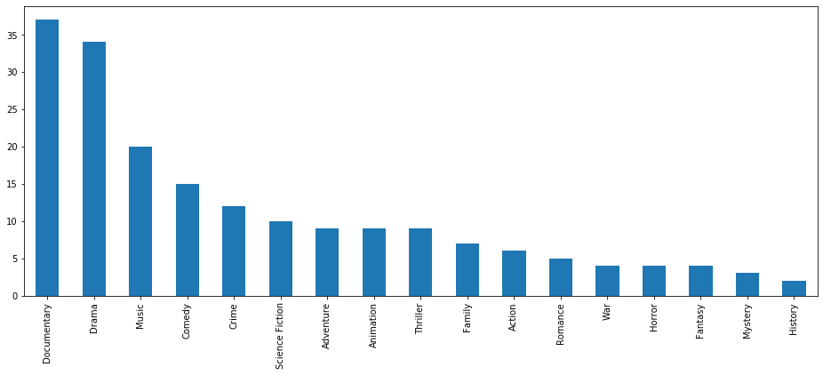

```python
total_movies_per_genero_top100_vote_average.sort_values(ascending=False).plot(kind='bar', figsize=(16, 6));
```

```python
# Possible correlation of variables in the dataset
df.corr()
```

|  | id | popularity | budget | revenue | runtime | vote_count | vote_average | release_year | profit |
| --- | --- | --- | --- | --- | --- | --- | --- | --- | --- |
| id | 1.000000 | -0.014350 | -0.141351 | -0.099227 | -0.088360 | -0.035551 | -0.058363 | 0.511364 | -0.074960 |
| popularity | -0.014350 | 1.000000 | 0.545472 | 0.663358 | 0.139033 | 0.800828 | 0.209511 | 0.089801 | 0.628991 |
| budget | -0.141351 | 0.545472 | 1.000000 | 0.734901 | 0.191283 | 0.632702 | 0.081014 | 0.115931 | 0.570182 |
| revenue | -0.099227 | 0.663358 | 0.734901 | 1.000000 | 0.162838 | 0.791175 | 0.172564 | 0.057048 | 0.976160 |
| runtime | -0.088360 | 0.139033 | 0.191283 | 0.162838 | 1.000000 | 0.163278 | 0.156835 | -0.117204 | 0.136036 |
| vote_count | -0.035551 | 0.800828 | 0.632702 | 0.791175 | 0.163278 | 1.000000 | 0.253823 | 0.107948 | 0.755905 |
| vote_average | -0.058363 | 0.209511 | 0.081014 | 0.172564 | 0.156835 | 0.253823 | 1.000000 | -0.117632 | 0.183109 |
| release_year | 0.511364 | 0.089801 | 0.115931 | 0.057048 | -0.117204 | 0.107948 | -0.117632 | 1.000000 | 0.032002 |
| profit | -0.074960 | 0.628991 | 0.570182 | 0.976160 | 0.136036 | 0.755905 | 0.183109 | 0.032002 | 1.000000 |

```python
# Possible correlation of variables in the dataset, for movies with budgets and revenues above 100 MM
df[ filter_revenue_100MM ].corr()
```

|  | id | popularity | budget | revenue | runtime | vote_count | vote_average | release_year | profit |
| --- | --- | --- | --- | --- | --- | --- | --- | --- | --- |
| id | 1.000000 | 0.271856 | 0.053897 | 0.044184 | 0.048210 | 0.171875 | 0.050570 | 0.526927 | 0.035908 |
| popularity | 0.271856 | 1.000000 | 0.341958 | 0.525042 | 0.165005 | 0.715972 | 0.367900 | 0.222471 | 0.504266 |
| budget | 0.053897 | 0.341958 | 1.000000 | 0.585407 | 0.158067 | 0.475919 | -0.023166 | 0.407487 | 0.401450 |
| revenue | 0.044184 | 0.525042 | 0.585407 | 1.000000 | 0.186382 | 0.685780 | 0.271905 | 0.177327 | 0.977553 |
| runtime | 0.048210 | 0.165005 | 0.158067 | 0.186382 | 1.000000 | 0.238623 | 0.364336 | -0.081083 | 0.169476 |
| vote_count | 0.171875 | 0.715972 | 0.475919 | 0.685780 | 0.238623 | 1.000000 | 0.497610 | 0.290371 | 0.651036 |
| vote_average | 0.050570 | 0.367900 | -0.023166 | 0.271905 | 0.364336 | 0.497610 | 1.000000 | -0.097379 | 0.313188 |
| release_year | 0.526927 | 0.222471 | 0.407487 | 0.177327 | -0.081083 | 0.290371 | -0.097379 | 1.000000 | 0.094427 |
| profit | 0.035908 | 0.504266 | 0.401450 | 0.977553 | 0.169476 | 0.651036 | 0.313188 | 0.094427 | 1.000000 |

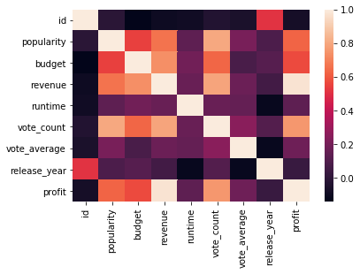

```python
# Heatmap graph for dataset correlation in Seaborn library
corr = df.corr()
sns.heatmap(corr);
```

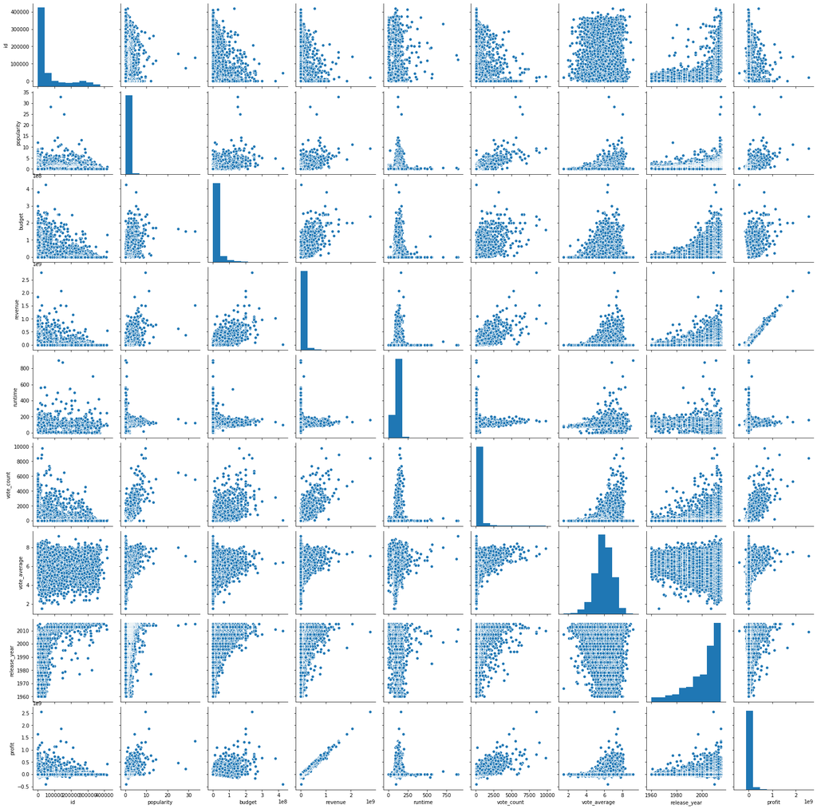

```python
# Pairplot graphs for dataset correlation in Seaborn library
sns.pairplot(df);
```

[figure not shown]